# Weekly Energy Charts

January 20, 2023

Sign up to receive our email updates via [Substack](https://leach.substack.com/)

[interactive chart not shown]

# Featured Stories

## A business case for LNG?

#### [Kayla Layden](https://www.linkedin.com/in/kaylalayden/)

Japanese Prime Minister Fumio Kishida visited Canada this week as part of a five-country tour as Japan takes over the presidency of the G7. One of the topics of interest: the possibility of increased liquid natural gas exports from Canada.

Ahead of Prime Minister Kishida’s arrival, Alberta Premier Danielle Smith sent [a letter to Prime Minister Trudeau](https://calgarysun.com/opinion/columnists/bell-smith-writes-trudeau-urges-yes-to-natural-gas-for-japan) urging him to agree to export more energy to Japan. The country’s desire for Canadian LNG is primarily driven by the world’s [“energy crisis”](https://nationalpost.com/news/politics/trudeau-energy-japan-canada-lng) and a desire to stop importing from Russia, previously about 10% of the Japanese natural gas supply. Fears of an energy shortage, like that faced in Europe last year, have led the G7 to exempt Japan from the [cap on Russian oil prices](https://calgaryherald.com/business/smith-calls-on-trudeau-to-bolster-energy-security-with-japan-during-kishidas-visit).

Throughout the meetings, Trudeau made no commitments regarding LNG exports and focused his statements and discussions on decarbonization and critical minerals. He announced that the government will lead a trade mission to Japan to discuss critical minerals and other opportunities this fall. A lack of commitment to LNG exports is somewhat unsurprising. German Chancellor Olaf Scholz visited Canada in late August, stressing his country’s desire to partner with Canada for gas. The Trudeau government expressed little interest stating that there has [“never been a strong business case”](https://nationalpost.com/news/canada/canada-germany-qatar-gas) for these kinds of exports. Trudeau focused on a hydrogen agreement instead. Germany has since gone elsewhere for LNG, signing a [fifteen-year agreement with Qatar](https://nationalpost.com/news/canada/canada-germany-qatar-gas).

[Original Article](https://nationalpost.com/news/politics/trudeau-energy-japan-canada-lng)

## Rare Earth Mining for Renewable Energy

#### [Marc Vermette](https://www.linkedin.com/in/marc-vermette/)

Michele Bustamante, a researcher at the USA Natural Resources Defense Council highlights the [importance of rare earth elements](https://www.iea.org/reports/the-role-of-critical-minerals-in-clean-energy-transitions/executive-summary) in the construction of renewable energy projects (wind turbine magnets, battery technology, etc.), but also points out the [worrying negative environmental effects](https://hir.harvard.edu/not-so-green-technology-the-complicated-legacy-of-rare-earth-mining/) of mining them (chemical spills, wastewater, pollution).

Thomas Lograsso, the director of the Critical Materials Institute highlights the importance of the mining industry’s desire to invest in more sustainable resource extraction practices to help resolve these negative effects.

It is the “low hanging fruit” that will yield the most results, like basic hardware upgrades, says Julie Klinger, a geographer at the University of Delaware.

While the only rare earth mine in North America, located in California, was [mostly inactive until recently](https://www.voanews.com/a/usa_california-mine-becomes-key-part-push-revive-us-rare-earths-processing/6200183.html), other locations are already feeling the effects of mining and processing these resources necessary for the renewable energy boom.

In 2010, China’s State Council wrote that the rare earth industry was causing “severe damage to the ecological environment.” The release of heavy metals and other pollutants during mining led to “destruction of vegetation and pollution.”

[Original Article](https://www.sciencenews.org/article/rare-earth-mining-renewable-energy-future)

## IEA Predicting Large Jump in Renewables

#### [Yousaff Habib](https://www.linkedin.com/in/yousaff-habib-6684891a5/)

The International Energy Agency’s (IEA) latest “Renewables 2022” report has some exciting news for the future of clean energy. The IEA has revised its predictions upward and now expects renewables - primarily solar and wind - to grow about 30% more than initially forecast. This is the largest upward adjustment the IEA has ever made. The report also predicts that renewables will account for over 90% of new global electricity capacity growth between now and 2027.

One of the main drivers behind this increase is energy security concerns, as countries that are dependent on Russian gas are looking to rapidly replace it with clean energy alternatives. However, the report also cites the impact of existing policies and regulatory and market reforms, as well as new ones that are being implemented more quickly than expected, in countries such as China, the European Union, the United States, and India.

The report predicts that solar energy production will nearly triple in the next five years, and that by 2027, it will surpass coal as the number one source of power capacity. Wind-generated energy is also expected to almost double in the next five years.

The IEA notes that the growth of renewable power capacity could even be faster than forecast with a few key changes, one of the most notable being quicker permitting of energy projects and transmission lines. This is an issue in the United States and Europe, where it can take an average of four and a half years to complete the environmental impact statements needed to permit major energy projects. With responsible permitting reform, the clean energy economy could receive a boost that will have positive effects for generations to come.

The full IEA report can be found [here](https://www.iea.org/reports/renewables-2022) and I strongly encourage anyone with an interest in renewable energy to at least skim it over. It’s full of interesting takeaways.

# Oil

## Weekly Crude Prices

### Feature Crude

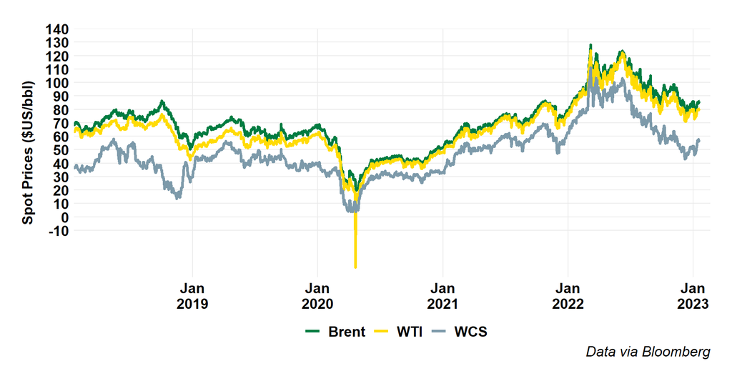

### Alberta Crude

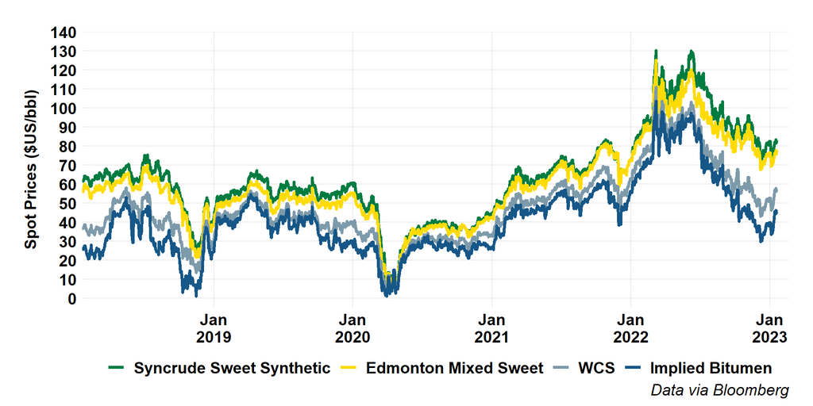

### Alberta Crude (Short)

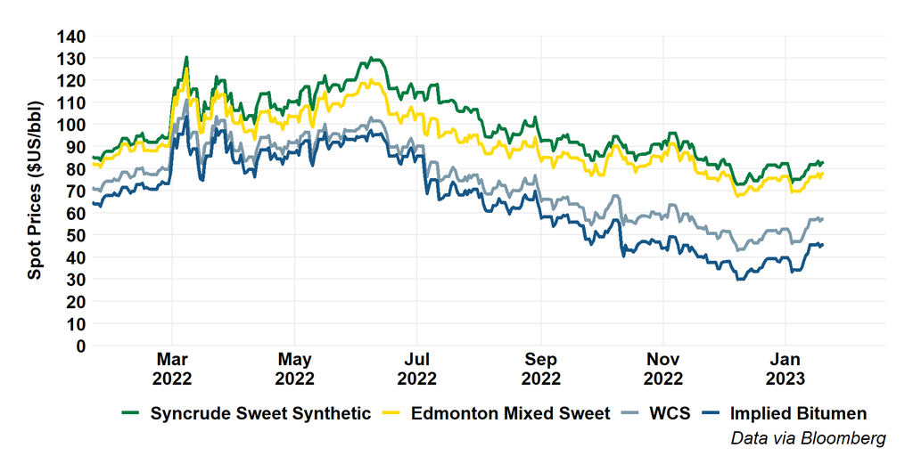

### US Crude

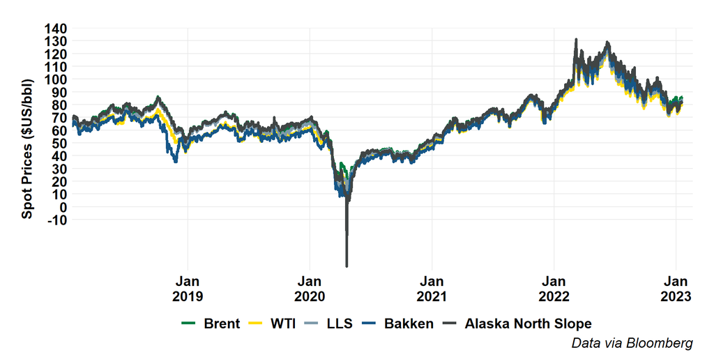

### Global Crude

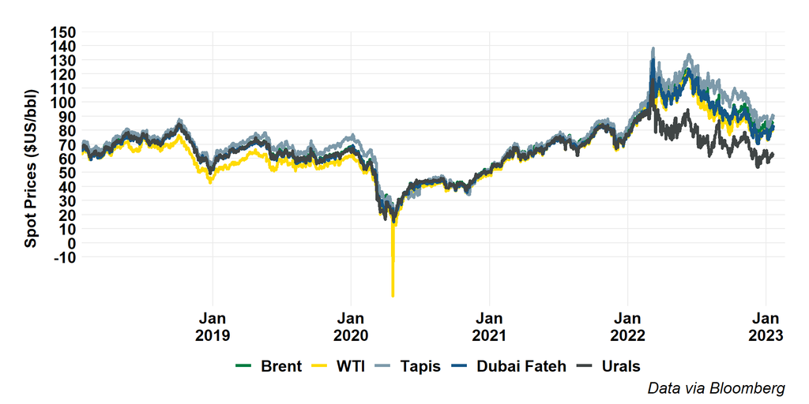

## Oil Price Differentials

### Brent-WTI

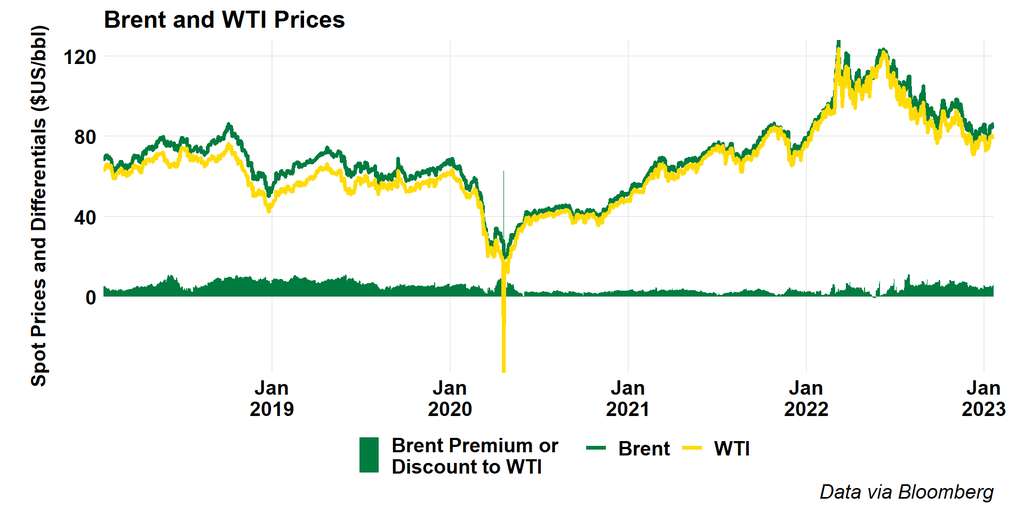

### WTI-WCS

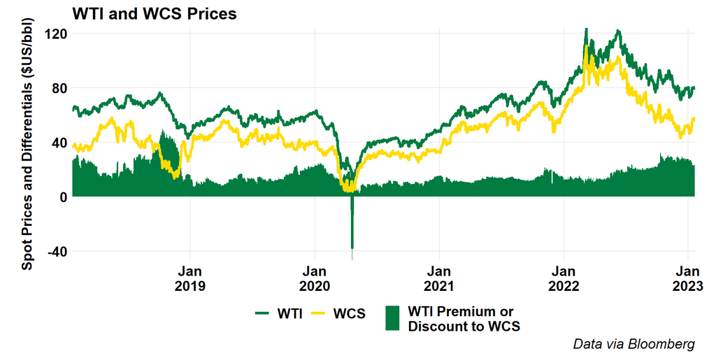

### WTI-WCS (Short)

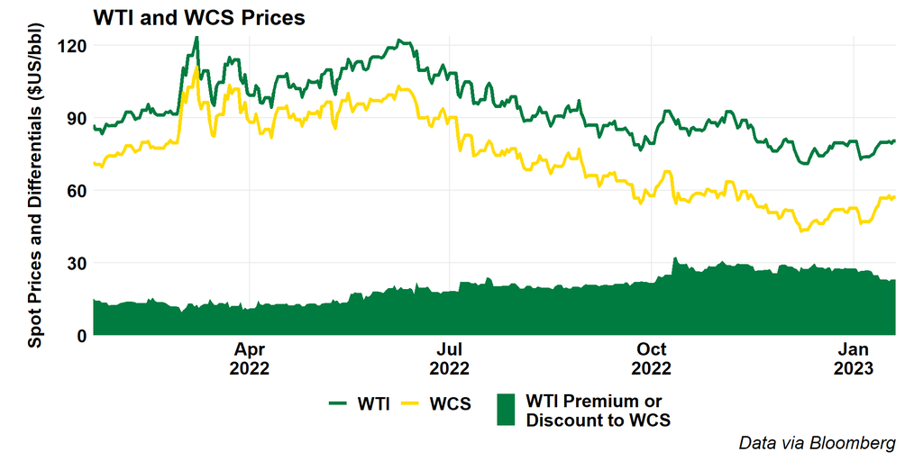

### Maya-WCS

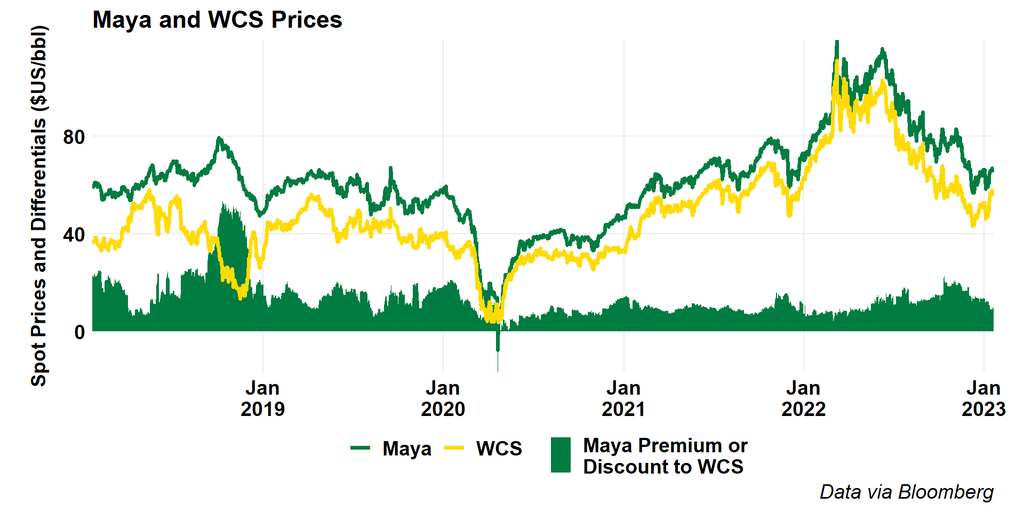

### WTI Cushing vs MEH

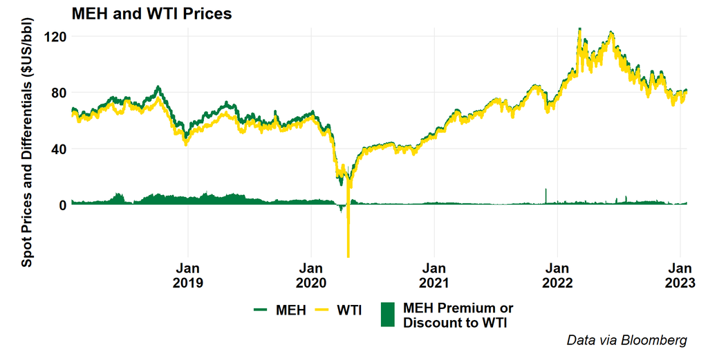

## Forward Curves

### WTI

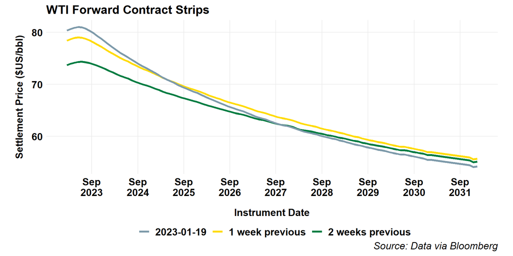

### Brent

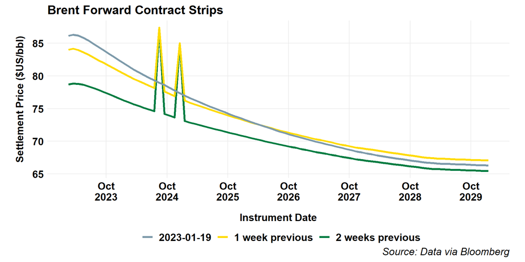

## Canadian Crude Supply and Disposition

### Canadian Production

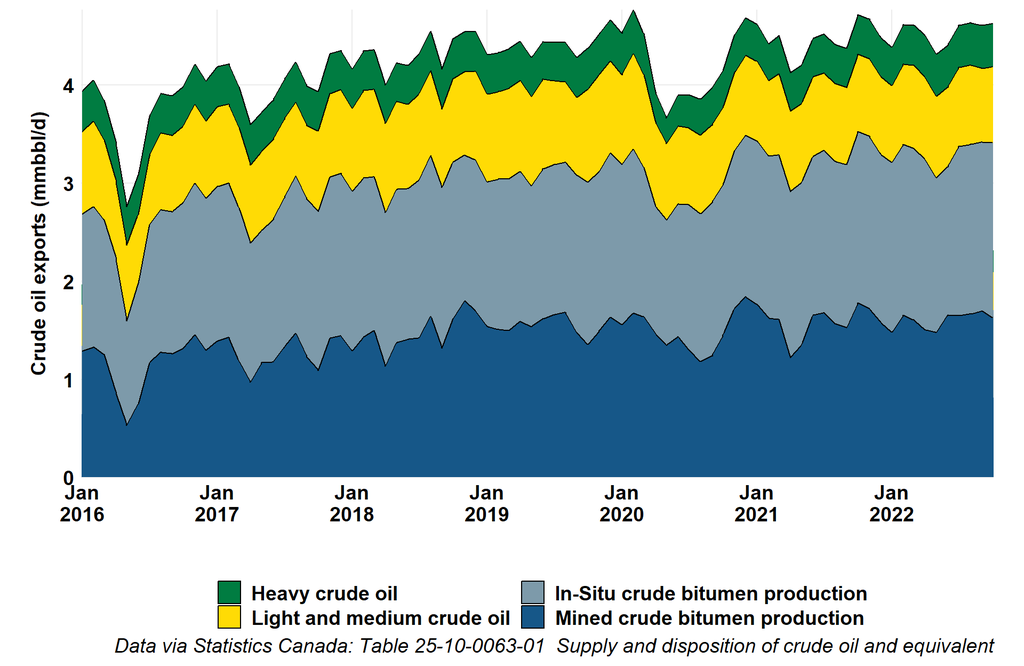

### Alberta Production

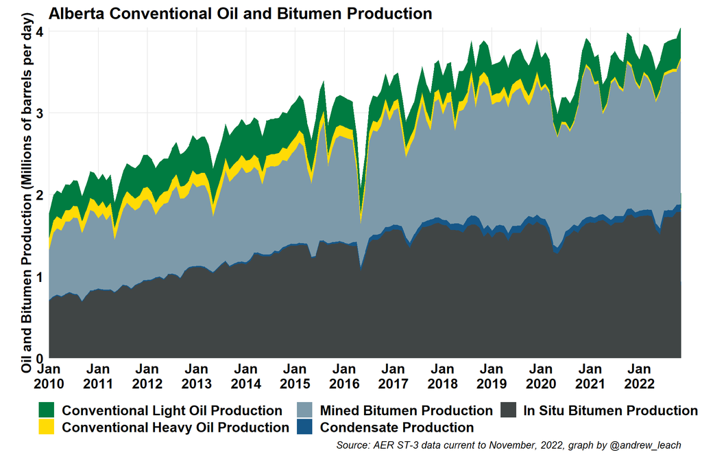

### Imports

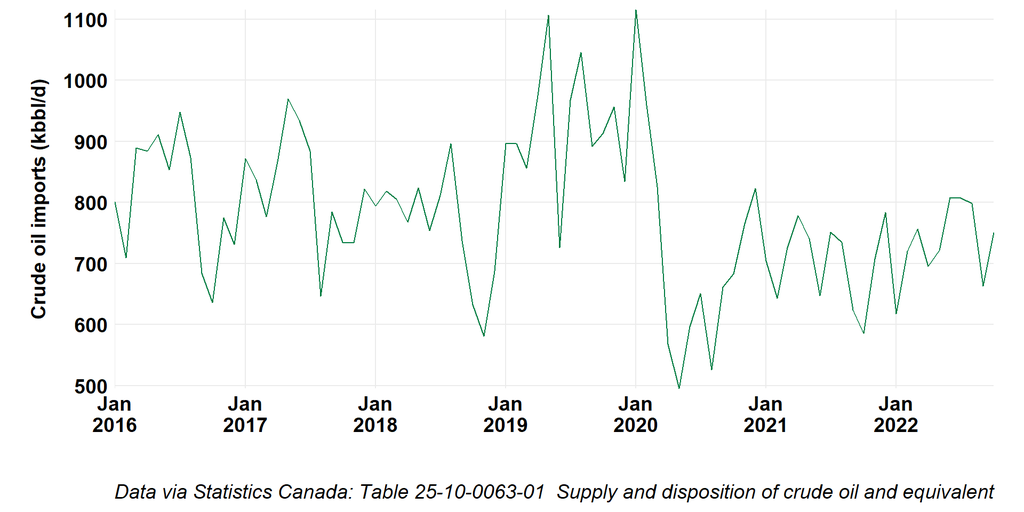

### Exports

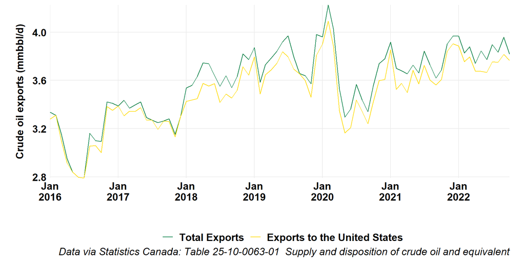

### Exports by Rail

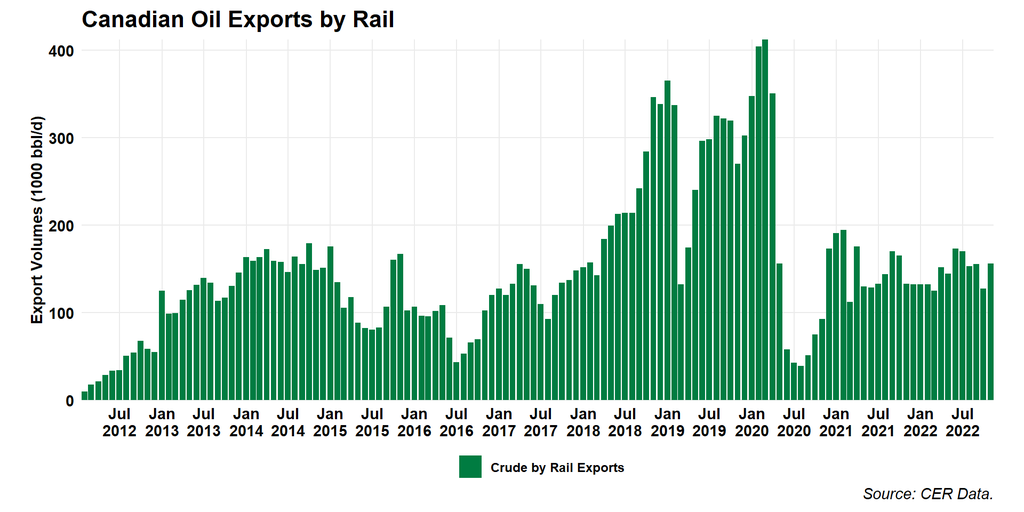

## US Oil

### Production

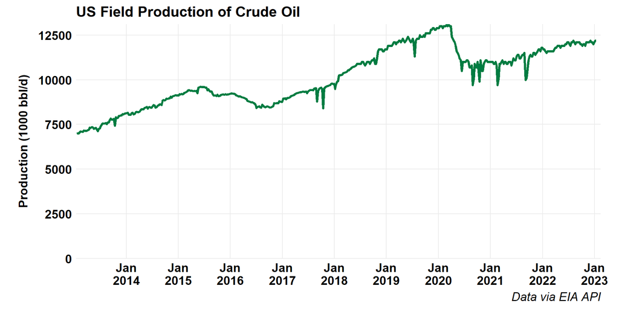

### LTO Production by Play

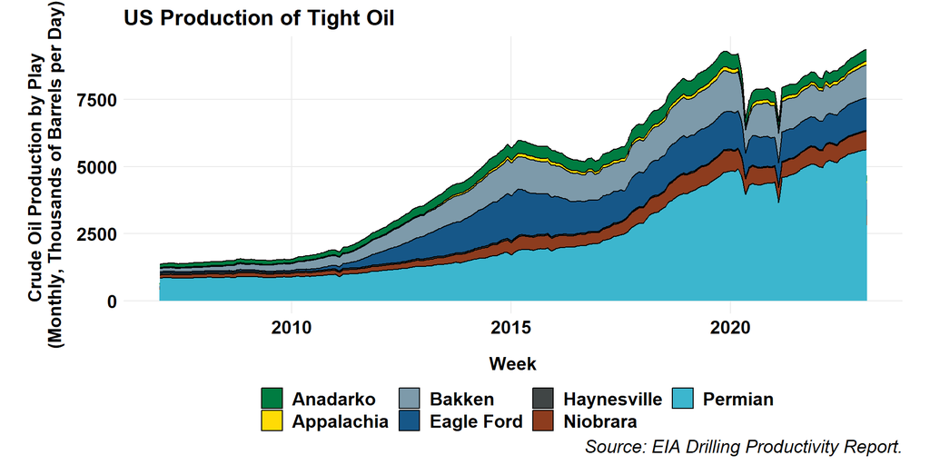

### Net Imports

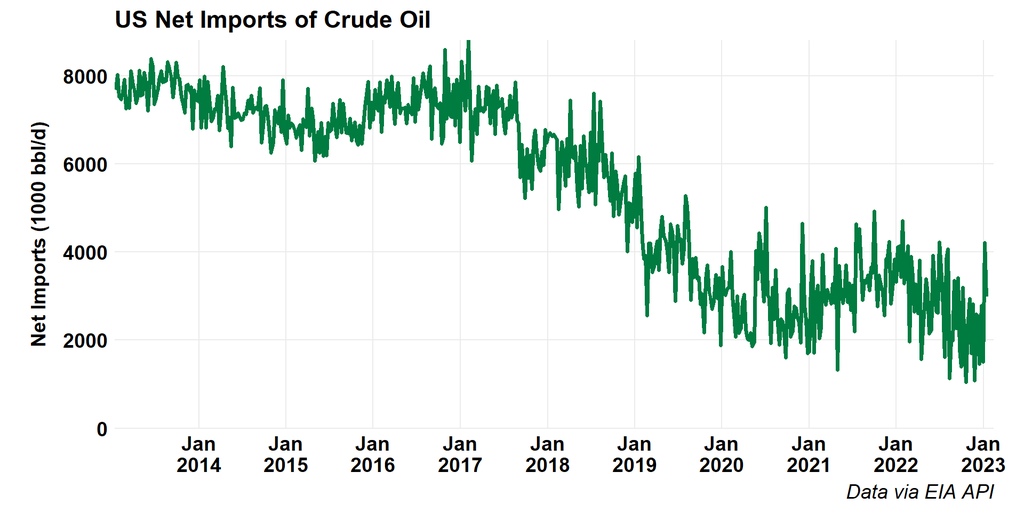

### Oil and Product Net Imports

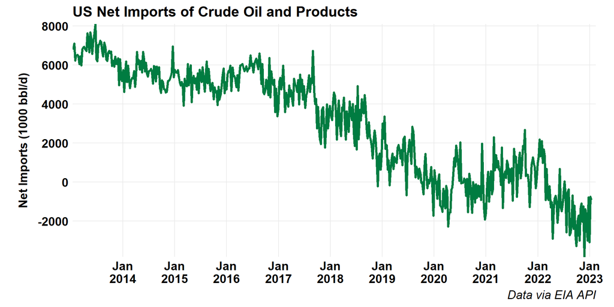

### Inventories

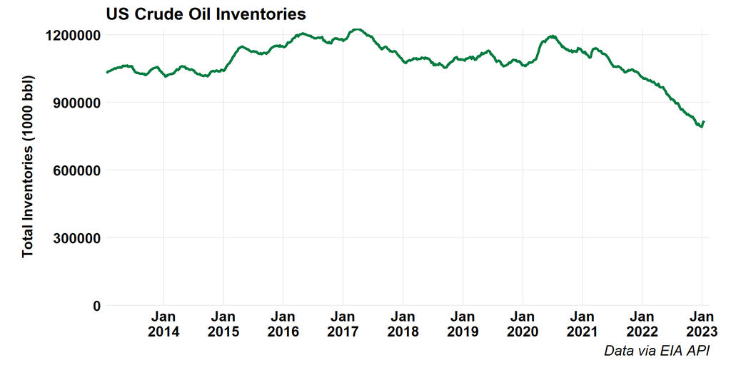

### EIA STEO Forecasts

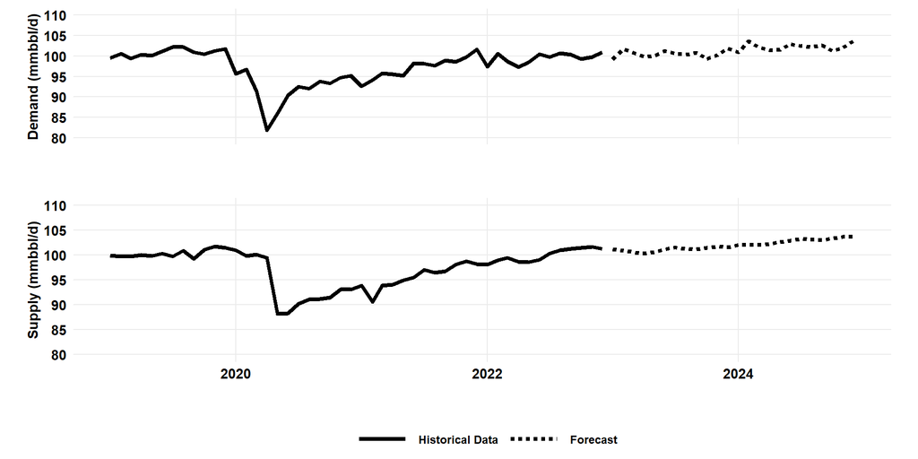

# Refined Products

## Canadian Gasoline Prices

### Map

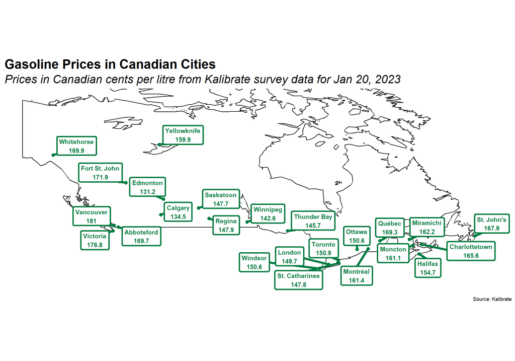

### Historic Gasoline Prices

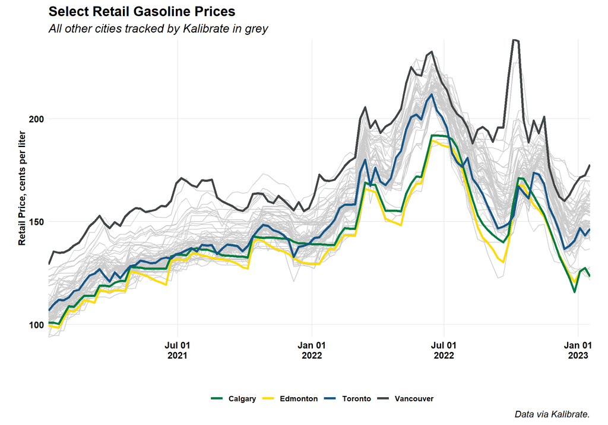

### Gasoline Prices in BTC

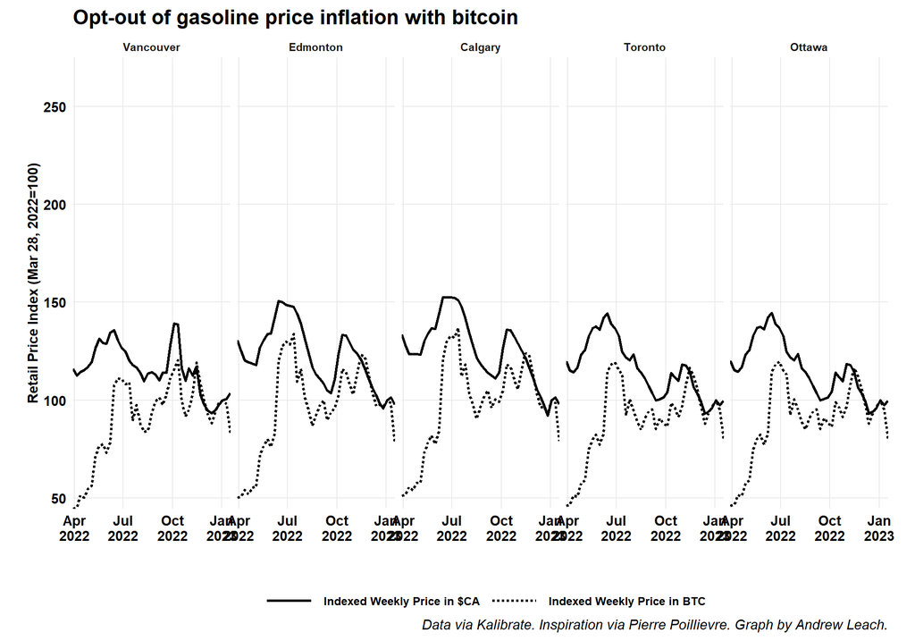

### Historic Diesel Prices

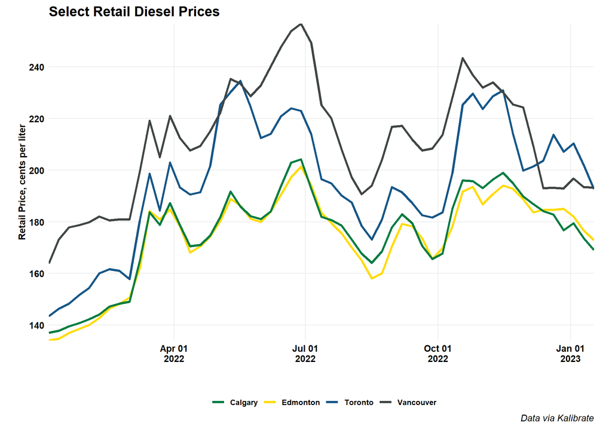

### Diesel Prices in BTC

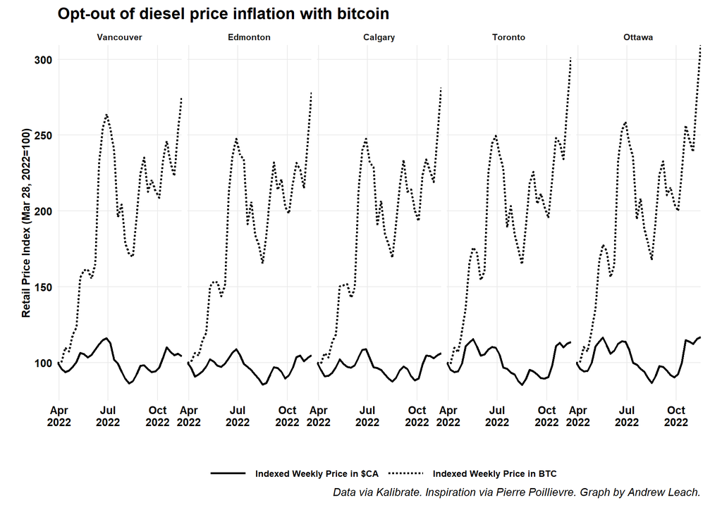

## Canadian Refinery Runs

### Canadian Refinery Runs

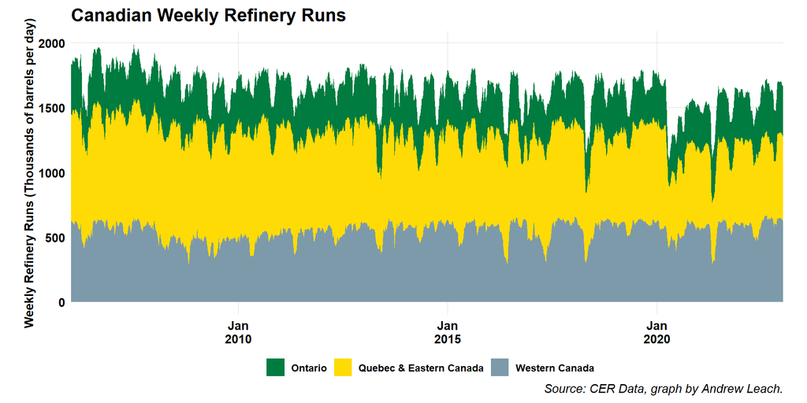

### Western Canada Refinery Runs

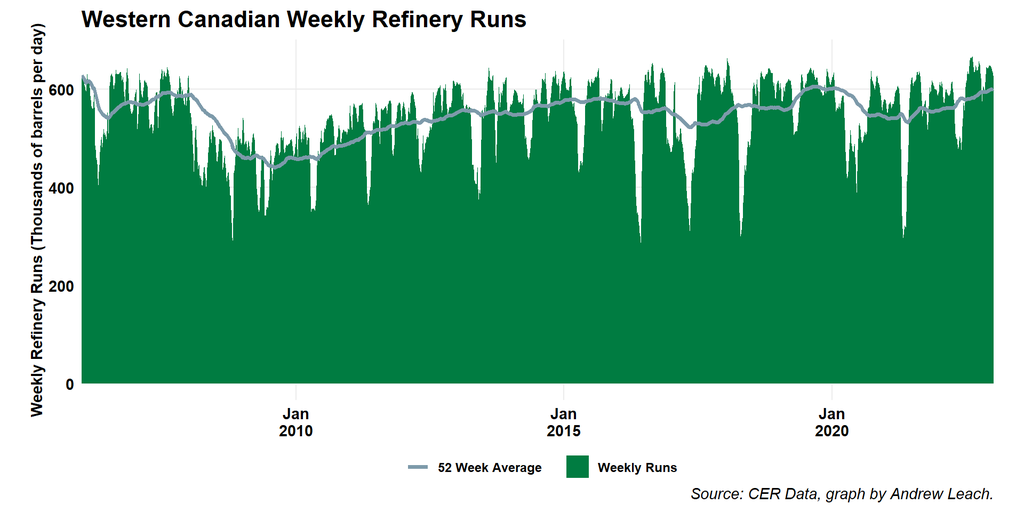